# DS002 Projects

## Outcome of Upsets

- Represents outcomes in round of 64 within 4 pools, where bottom seed group is all teams seeded from 8-16 and top seed group is all teams seeded 1-8

```
# A tibble: 4 × 3
# Groups:   seed_group [2]
  seed_group RESULT `n()`
  <chr>      <chr>  <int>
1 bottom     loss      25
2 bottom     win        7
3 top        loss       7
4 top        win       25
```

Upset rate (7/32):

```
[1] 0.21875
```

P-Value:

```
[1] 0.035
```

## Null Distribution

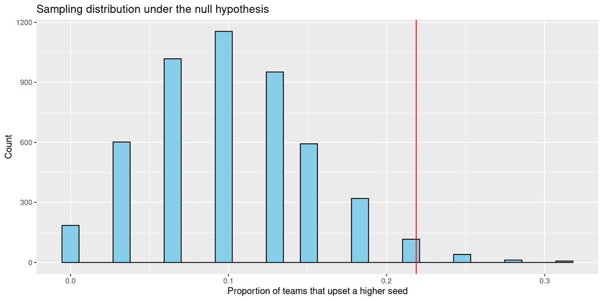

## Key Insights

- Upset rate: 21.9%, much higher than 10%.
- P-value: 0.035 — rejected null hypothesis, less than significance level (0.05).
- Lower-seeded teams can achieve significant upsets.

## WAI Database Analysis

- Compared sex-based differences in absorbency for Aithal (2013).
- Data pulled from Aithal study in WAI database

## Data

```
    Identifier Frequency     Sex Mean_Absorbance Unique_Ears
1  Aithal_2013       250  Female       0.7233140           1
2  Aithal_2013       250  Female       0.5436131          66
3  Aithal_2013       250    Male       0.5444056          66
4  Aithal_2013       250 Unknown       0.6231640           3
5  Aithal_2013       300  Female       0.5790744           1
6  Aithal_2013       300  Female       0.5163662          66
7  Aithal_2013       300    Male       0.5221938          66
8  Aithal_2013       300 Unknown       0.5825467           3
9  Aithal_2013       400  Female       0.5225532           1
10 Aithal_2013       400  Female       0.4348804          66
11 Aithal_2013       400    Male       0.4434407          66
12 Aithal_2013       400 Unknown       0.4734422           3
13 Aithal_2013       500  Female       0.5307322           1
14 Aithal_2013       500  Female       0.4072390          66
```

[output cut: 50 more lines]

## Analysis by Sex (using the *Aithal (2013)* study)

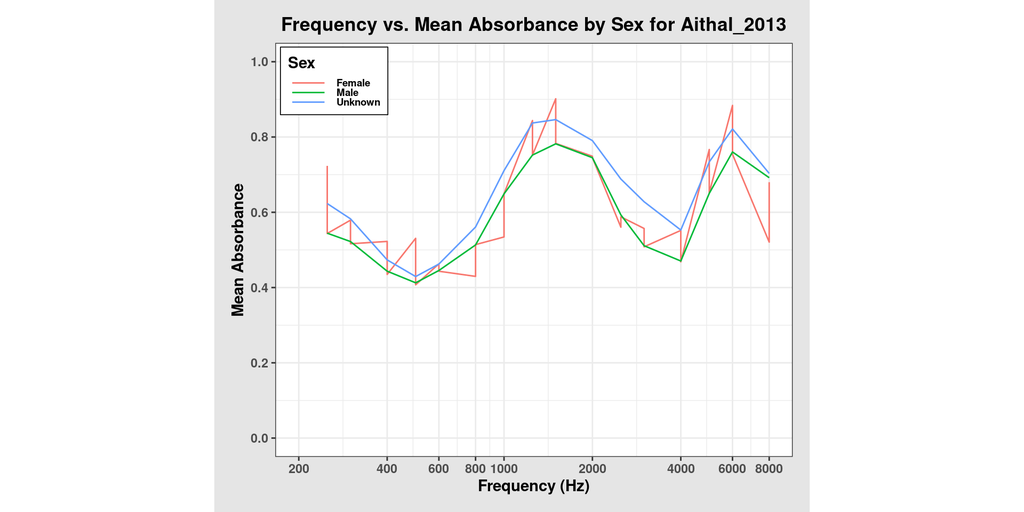

## Key Insights

- Not a major difference between mean absorbency across frequencies between sexes
- Sex does not influence auditory outcomes